# RFinalProject_ShutimaP

Shutima P

1/7/2020

# R for Big Data Final Project: Exploratory Data Analysis of Airbnb Database by Shutima Potivorakun

## Loading the data from Rdata file

```r
load('AirBnB.Rdata')
```

## Descriptive Analysis

```r
summary(L)
```

[output not shown]

[output cut: 337 more lines]

```
##  f:51014                          Min.   :  1.000
##  t: 1711                          1st Qu.:  1.000
##                                   Median :  1.000
##                                   Mean   :  4.087
##                                   3rd Qu.:  1.000
##                                   Max.   :155.000
##
##  reviews_per_month
##  Min.   : 0.010
##  1st Qu.: 0.360
##  Median : 0.900
##  Mean   : 1.336
##  3rd Qu.: 1.870
##  Max.   :14.290
##  NA's   :14508
```

## Check table L

```r
View(L)
```

## Data treatment

We need to use the price columns (including weekly_price and monthly_price) but the raw data contains the price data prefixed with `$` and with `,` for thousand delimiter, and not yet in a numeric format. Therefore we need to remove all `$` symbols and also `,` from this column and change the data to numeric type. We will do this using as.numeric and gsub functions.

```r
# Changing the price columns from character to numeric by removing $ and consider the decimal point
L$price <- as.numeric(gsub('\\$|,', '', L$price))
L$weekly_price <- as.numeric(gsub('\\$|,', '', L$weekly_price))
L$monthly_price <- as.numeric(gsub('\\$|,', '', L$monthly_price))
#L$price
#L$weekly_price
#L$monthly_price
```

```r
# Check missing values with below command in R console
# colSums(is.na(L))
# The result shows that column neighbourhood_group_cleansed and has_availability are completely empty therefore we drop these 2 columns
L$neighbourhood_group_cleansed <- NULL
L$has_availability <- NULL

# Replace missing numerical values with the column median
nums <- unlist(lapply(L, is.numeric))
for (nm in names(nums)) {
  #print(nm)
  #print(nums[[nm]])
  if (nums [[nm]]) {
    myna <- is.na(L[[nm]])
    mycol <- L[[nm]]
    mycol[myna] <- median(L[[nm]], na.rm = TRUE)
    L[[nm]] <- mycol
  }
}

# Recheck for missing values
colSums(is.na(L))
```

```
##                               id                      listing_url
##                                0                                0
##                        scrape_id                     last_scraped
##                                0                                0
##                             name                          summary
##                                0                                0
##                            space                      description
##                                1                                0
##              experiences_offered            neighborhood_overview
##                                0                                1
##                            notes                          transit
##                                3                                1
##                           access                      interaction
##                                1                                1
##                      house_rules                    thumbnail_url
##                                1                                0
##                       medium_url                      picture_url
##                                0                                0
##                   xl_picture_url                          host_id
##                                0                                0
##                         host_url                        host_name
##                                0                                0
##                       host_since                    host_location
##                                0                                0
##                       host_about               host_response_time
##                                5                                0
##               host_response_rate             host_acceptance_rate
##                                0                                0
##                host_is_superhost               host_thumbnail_url
##                                0                                0
##                 host_picture_url               host_neighbourhood
##                                0                                0
##              host_listings_count        host_total_listings_count
##                                0                                0
##               host_verifications             host_has_profile_pic
##                                0                                0
##           host_identity_verified                           street
##                                0                                0
##                    neighbourhood           neighbourhood_cleansed
##                                0                                0
```

[output cut: 39 more lines]

```
##                                0                                0
##            review_scores_checkin      review_scores_communication
##                                0                                0
##           review_scores_location              review_scores_value
##                                0                                0
##                 requires_license                          license
##                                0                                0
##               jurisdiction_names                 instant_bookable
##                                0                                0
##              cancellation_policy    require_guest_profile_picture
##                                0                                0
## require_guest_phone_verification   calculated_host_listings_count
##                                0                                0
##                reviews_per_month
##                                0
```

Test that there is no problem to process the data by plotting a histogram of price column

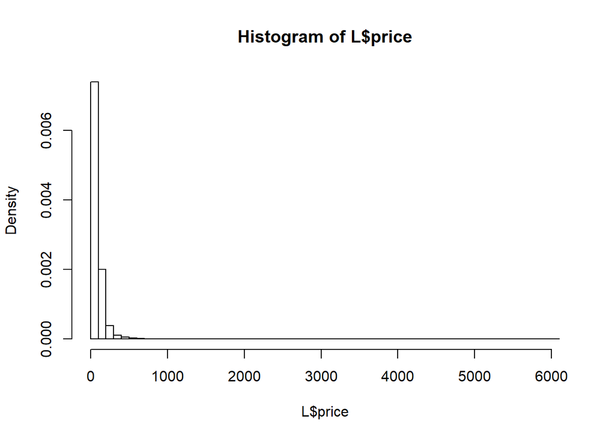

```r
# Loading ggplot
library(ggplot2)
hist(L$price, breaks = 50, freq = FALSE)
```

## Question 1: Relationship between apartment prices and apartment features

1. Relationship between apartment prices and apartment neighbourhood using ggplot Here we will represent the average apartment price per neighbourhood.

```r
library(tidyverse)
```

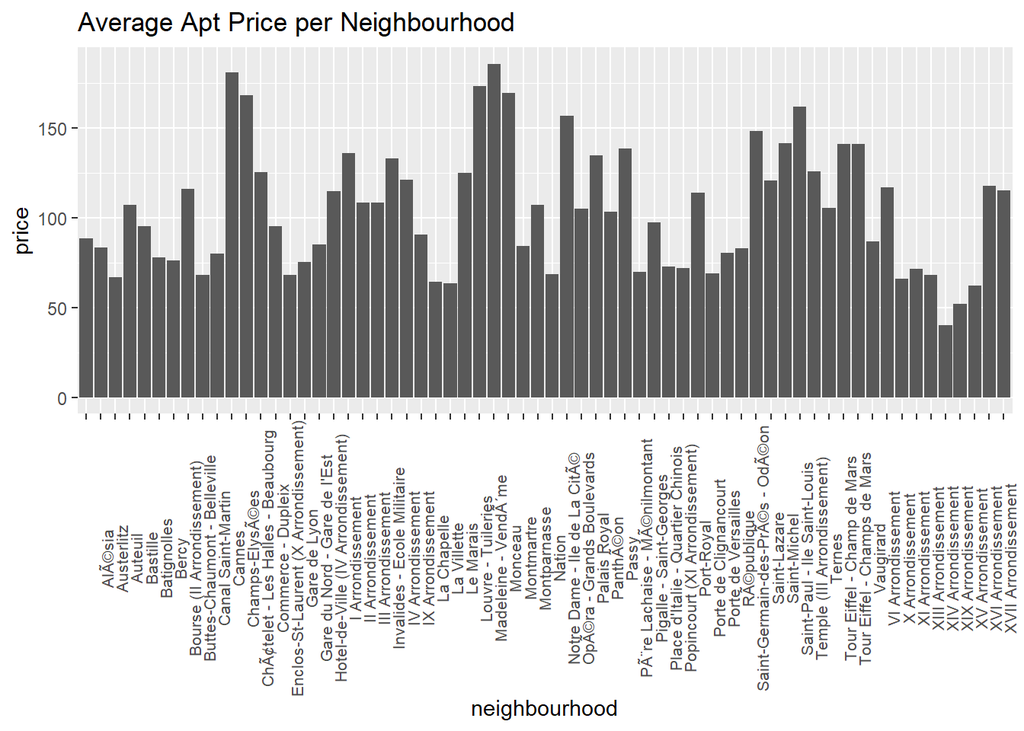

```r
p <- L %>%
  group_by(neighbourhood) %>%
  summarize(price = mean(price)) %>%
  ggplot(aes(y = price, x = neighbourhood)) +
  geom_col() +
  theme(axis.text.x = element_text(size = 8, angle = 90)) +
  ggtitle("Average Apt Price per Neighbourhood")
p
```

2. Relationship between apartment prices and apartment room_type using ggplot This relationship shows that there are 3 types of apartment types:
- Entire home/apt
- Private room
- Shared room The price to rent an entire home/apt is the most expensive, when shared room type is the cheapest

```r
# Create new data frame with columns Price and Room Type

tmpRT<-data.frame(L$room_type, L$price)
#tmpRT
```

Then use `aggregate()` to compute the average apartment price per room type then store the result in the new data frame

```r
tmpRT_new <- aggregate(x = tmpRT$L.price, by = list(tmpRT$L.room_type), function(x) mean(x))
#tmpRT_new
```

Finally, use ggplot to plot the relationship of average apartment price per room type

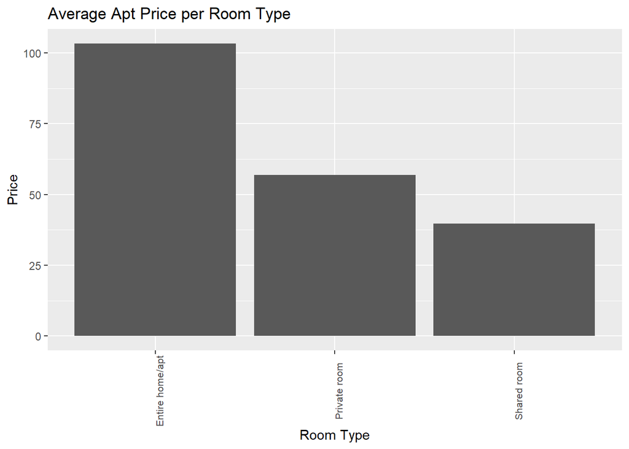

```r
p2 <- tmpRT_new %>%
  group_by(Group.1) %>%
  summarize(x = mean(x)) %>%
  ggplot(aes(y = x, x = Group.1)) +
  geom_col() +
  theme(axis.text.x = element_text(size = 8, angle = 90)) + ylab("Price") + xlab("Room Type") +
  ggtitle("Average Apt Price per Room Type")
p2
```

3. Relationship between apartment prices and apartment bed_type using ggplot This graph shows that there are 5 bed types:
- Airbed
- Couch
- Futon
- Pull-out Sofa
- Real bed Here, it shows that the apartments with real beds are the most expensive, while the apartments with airbeds are the cheapest to rent.

```r
# Show relationship between apartment price and the bed type using ggplot
# Create new data frame with columns Price and Bed Type
tmpBT<-data.frame(L$bed_type, L$price)
#tmpBT
```

Then use `aggregate()` to compute the average apartment price per bed type then store the result in the new data frame

```r
tmpBT_new <- aggregate(x = tmpBT$L.price, by = list(tmpBT$L.bed_type), function(x) mean(x))
#tmpBT_new
```

Finally, use ggplot to plot the relationship of average apartment price per bed type

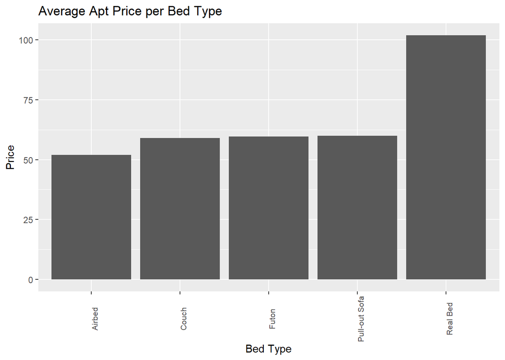

```r
p3 <- tmpBT_new %>%
  group_by(Group.1) %>%
  summarize(x = mean(x)) %>%
  ggplot(aes(y = x, x = Group.1)) +
  geom_col() +
  theme(axis.text.x = element_text(size = 8, angle = 90)) + ylab("Price") + xlab("Bed Type") +
  ggtitle("Average Apt Price per Bed Type")
p3
```

## Question 2: Number of apartments per owner

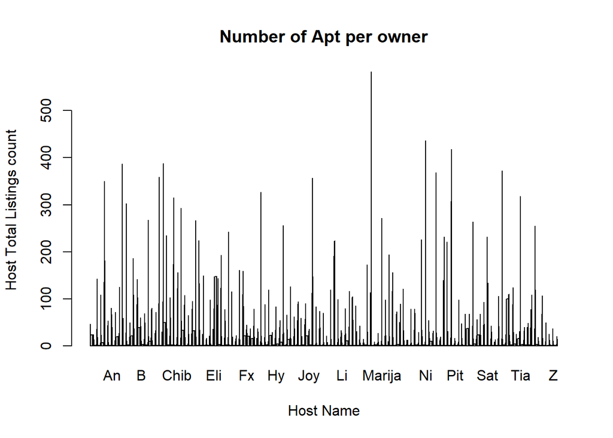

```r
count <- table(L$host_total_listings_count)
countHN <- table(L$host_name)
barplot(countHN, count, main = "Number of Apt per owner", xlab = "Host Name", ylab = "Host Total Listings count")
```

## Question 3: Rent Price per City Quarter (“arrondissements”)

Here we would like to represent the relationship of the average apartment price per arrondissements (Paris Zip Code), so we need to use the price and zipcode columns from the database

```r
# Create new data frame with columns Price and Zipcode

tmpAR<-data.frame(L$zipcode, L$price)
#tmpAR
```

Then use `aggregate()` to compute the average apartment price per arrondissement then store the result in the new data frame

```r
tmpAR_new <- aggregate(x = tmpAR$L.price, by = list(tmpAR$L.zipcode), function(x) mean(x))
#tmpAR_new
```

Finally, use ggplot to plot the relationship of average apartment price per arrondissement

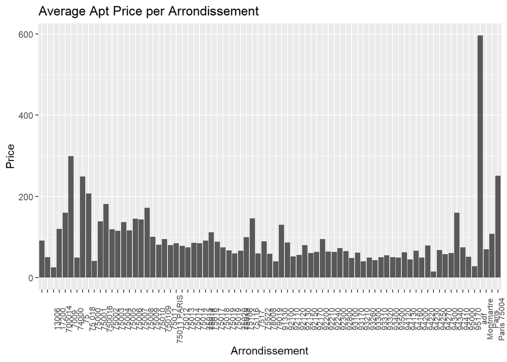

```r
p4 <- tmpAR_new %>%
  group_by(Group.1) %>%
  summarize(x = mean(x)) %>%
  ggplot(aes(y = x, x = Group.1)) +
  geom_col() +
  theme(axis.text.x = element_text(size = 8, angle = 90)) + ylab("Price") + xlab("Arrondissement") +
  ggtitle("Average Apt Price per Arrondissement")
p4
```

## Question 4: Visit frequency of the different quarters according to time.

We will use the columns zipcode and `reviews_per_month` for this representation as the column `reviews_per_month` can tell us which quarters (arrondissement) has the most reviews per month (most visited).

This ggplot below shows us that the quarter (arrondissement) 93170, or Bagnolet, has the most reviews per month. Or, is the most visited quarter in Paris.

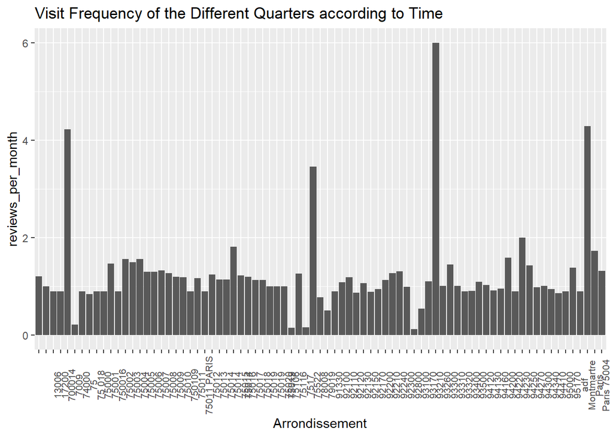

```r
p5 <- L %>%
  group_by(zipcode) %>%
  summarize(reviews_per_month = mean(reviews_per_month)) %>%
  ggplot(aes(y = reviews_per_month, x = zipcode)) +
  geom_col() +
  theme(axis.text.x = element_text(size = 8, angle = 90)) + xlab("Arrondissement") +
  ggtitle("Visit Frequency of the Different Quarters according to Time")
p5
```

```r
#install.packages("shiny")
library(shiny)
```

# That’s all folks! I hope you enjoyed my reports :)